# Tensors

```python
import torch
```

```python
def activation(x, func=None):
  """
  Arguments
  ---------
  x: torch.tensor
  """
  if func == 'softmax':

    #dim =1 takes sum over the rows.
    return torch.exp(x)/torch.sum(torch.exp(x), dim=1).view(-1, 1)

  return 1/(1+torch.exp(-x))
```

Below explains the view(it only changes the shape for veiwing) but in memory the shape is retained. A value of negative 1 means the shape if inferred from the tensor.

```
In [21]: a
Out[21]:
tensor([[ 1,  0,  0],
        [ 1,  1,  1],
        [-1,  1,  1],
        [ 2,  3,  4]])

In [22]: a.sum(dim=1).view(-1, 1)
Out[22]:
tensor([[1],
        [3],
        [1],
        [9]])

In [23]: a/a.sum(dim=1).view(-1, 1)
Out[23]:
tensor([[ 1.0000,  0.0000,  0.0000],
        [ 0.3333,  0.3333,  0.3333],
        [-1.0000,  1.0000,  1.0000],
        [ 0.2222,  0.3333,  0.4444]])

In [24]:
```

```python
#Generate data for example.
torch.manual_seed(7)

#features
features = torch.randn((1, 5))

#weights
weights = torch.randn_like(features)
#bias
bias = torch.randn((1, 1))
```

```python
print(f"F:{features},\nW:{weights},\nb:{bias}")
```

```
F:tensor([[-0.1468,  0.7861,  0.9468, -1.1143,  1.6908]]),
W:tensor([[-0.8948, -0.3556,  1.2324,  0.1382, -1.6822]]),
b:tensor([[0.3177]])
```

```python
#Using matrix multuplication change the shape of second tensor to match with number of columns of features.
#Functions that can be used torch.reshape(), torch.resize(), torch.view()

activation((torch.matmul(features, weights.T))+bias)
```

```
tensor([[0.1595]])
```

```python
weights.shape
```

```
torch.Size([1, 5])
```

```python
activation(torch.sum(features*weights)+bias)
```

```
tensor([[0.1595]])
```

```python
#Torch has a function torch.from_numpy() to convert numpy array to tensors.
import numpy as np

np.random.seed(13)
torch.from_numpy(np.random.randint(10,size=(5, 2)))
```

```
tensor([[2, 0],
        [0, 6],
        [2, 4],
        [9, 3],
        [4, 2]])
```

NOTE: If any value is changed in-place for one object then the other value changes as well. Both have a shared memory.

# Neural Networks

We will use the MNIST dataset of handwritten examples of digits in postcards which is pre-processed and formatted. This dataset can be loaded with `torchvision`in pytorch.

```python
from torchvision import datasets, transforms

#Normalizing the data using transform

transform= transforms.Compose([transforms.ToTensor(),transforms.Normalize((0.5,),(0.5,))])

#Download and load the MNIST dataset

trainset = datasets.MNIST('MNIST_data/',download=True, train=True, transform = transform)
trainloader = torch.utils.data.DataLoader(trainset, batch_size=64, shuffle=True)
```

[output not shown]

[output not shown]

[output not shown]

[output not shown]

[output not shown]

Tensor of size (64, 1, 28, 28) that it is a batch of 64 images with 1 channel of 28 * 28 pixel. Note that an (d1, d2, ..., dn)-dimensional array/tensor is represented as follows.

Each $d_i$ represents the length of the list we will have "list of $d_1$ lists each containing $d_2$ lists with $d_3$ lists and so on..."

```python
iter_data = iter(trainloader)
images, labels = next(iter_data)
print(images.shape)
print(labels.shape)
```

```
torch.Size([64, 1, 28, 28])
torch.Size([64])
```

```python
import matplotlib.pyplot as plt
%matplotlib inline
```

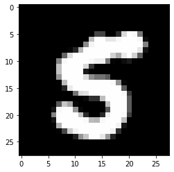

```python
plt.imshow(images[1].numpy().squeeze(), cmap='Greys_r')
```

```python
#Input images of size 64*784 where each row is of size 28*28 = 784
torch.manual_seed(13)
img_input = torch.flatten(images, start_dim=1)

#Assiging weights to the first layer which will have 684 weights with respect to each hidden units.
W_1 = torch.randn((784, 256))
bias = torch.randn((256))

#Assiging weights to the output layer

W_2 = torch.randn((256, 10))
bias1 = torch.randn((10))

#Using sigmoid as activation and output function
out = activation(torch.matmul(activation(torch.matmul(img_input, W_1)+bias), W_2)+bias1)

#Using softmax for activation and output function
out1 = activation(torch.matmul(activation(torch.matmul(img_input, W_1)+bias, func='softmax'), W_2)+bias1, func='softmax')

#Using sigmoid for activation and softmax for final ouput.
out2 = activation(torch.matmul(activation(torch.matmul(img_input, W_1)+bias), W_2)+bias1, func='softmax')
```

```python
torch.sum(torch.matmul(img_input, W_1)+bias, dim=0).shape
```

```
torch.Size([256])
```

```python
torch.flatten(images, start_dim=1).shape
```

```
torch.Size([64, 784])
```

```python
import seaborn as sns
```

Plotting the probabilities of the above network which is not trained.

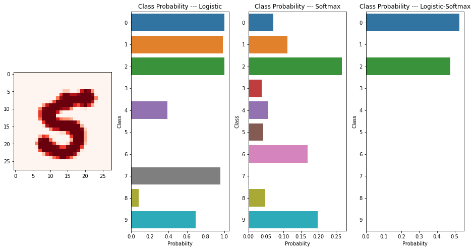

```python
fig, ax = plt.subplots(nrows=1, ncols=4,figsize=(16, 8))


#First input image of the 64 images.
ax[0].imshow(img_input[1].numpy().reshape((28, 28)).squeeze(),cmap='Reds')

#Proba class of network without training
sns.barplot(y=list(range(10)), x=out[:1,:].numpy().squeeze(), ax=ax[1], orient='h')
ax[1].set_title('Class Probability --- Logistic')
ax[1].set_xlabel('Probabiity')
ax[1].set_ylabel('Class')

#Proba class using softmax.
sns.barplot(y=list(range(10)), x=out1[:1, :].numpy().squeeze(), ax=ax[2], orient='h')
ax[2].set_title('Class Probability --- Softmax')
ax[2].set_xlabel('Probabiity')
ax[2].set_ylabel('Class')


#Proba class using softmax.
sns.barplot(y=list(range(10)), x=out2[:1, :].numpy().squeeze(), ax=ax[3], orient='h')
ax[3].set_title('Class Probability --- Logistic-Softmax')
ax[3].set_xlabel('Probabiity')
ax[3].set_ylabel('Class')
```

```python
out2.sum(dim=1)
```

```
tensor([1.0000, 1.0000, 1.0000, 1.0000, 1.0000, 1.0000, 1.0000, 1.0000, 1.0000,
        1.0000, 1.0000, 1.0000, 1.0000, 1.0000, 1.0000, 1.0000, 1.0000, 1.0000,
        1.0000, 1.0000, 1.0000, 1.0000, 1.0000, 1.0000, 1.0000, 1.0000, 1.0000,
        1.0000, 1.0000, 1.0000, 1.0000, 1.0000, 1.0000, 1.0000, 1.0000, 1.0000,
        1.0000, 1.0000, 1.0000, 1.0000, 1.0000, 1.0000, 1.0000, 1.0000, 1.0000,
        1.0000, 1.0000, 1.0000, 1.0000, 1.0000, 1.0000, 1.0000, 1.0000, 1.0000,
        1.0000, 1.0000, 1.0000, 1.0000, 1.0000, 1.0000, 1.0000, 1.0000, 1.0000,
        1.0000])
```

```python
from torch import nn

#Build a forward network
#Note that the input is a batch of 64 flattened images, that is matrix of size (64, 784).
#Each column of the matrix corresponds to weights associated to the neuron.
#(64, 784)*(784, 128)*(128, 64)*(64, 10)=(64, 10)
#The result is probability for each image in the batch.

model = nn.Sequential(nn.Linear(784, 128),nn.ReLU(),nn.Linear(128, 64),nn.ReLU(),nn.Linear(64, 10), nn.LogSoftmax(dim=1))

#Loss function
criterion = nn.NLLLoss()

#data
images, labels = next(iter(trainloader))

#Flatten images
images = images.view(images.shape[0], -1)

logits = model(images)

#loss calculation
loss =  criterion(logits, labels)

print(loss)
```

```
tensor(2.3218, grad_fn=<NllLossBackward>)
```

```python
logits.shape
```

```
torch.Size([64, 10])
```

# Autograd

Autograd is reverse automatic differentiation system and a good introduction is provided on the pytorch [page](https://pytorch.org/tutorials/beginner/blitz/autograd_tutorial.html).

We require error associated with output of each neuron and to rectify it we require certain partial derivatives and autograd simplies this task by keeping track of the operations associated with scalar. In simple terms autograd stores the jacobian, it is simply the derivative(linear transformation) of multivariable function and give any vector $v$ (the direction of derivative) it gives out $Jv$.

## Mechanics

Note that partial derivatives can be represented by a tree

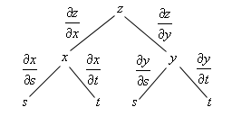

So if we want to calculate $\partial z/\partial s$ we get this by adding up the values in the above tree. So it would be \begin{equation} \frac{\partial z}{\partial s}= \frac{\partial z}{\partial x} \frac{\partial x}{\partial s} + \frac{\partial z}{\partial y} \frac{\partial y}{\partial s} \end{equation} In a similar manner autograd calculates the partial derivatives for the requires function. From the documentaion:

*Autograd relies on the user to write thread safe C++ hooks. If you want the hook to be correctly applied in multithreading environment, you will need to write proper thread locking code to ensure the hooks are thread safe.*

In python we don't need to worry because GIL.

## Example

In the following example we use the flag `requires_grad=True` to keep track of the operations on the tensor

```python
#Autograd
#To keep  a track of operations that created the tensor we have to set requires_grad = True.
x = torch.randn(2, 2, requires_grad=True)
x
```

```
tensor([[ 0.9017, -0.4343],
        [ 0.1861,  0.1828]], requires_grad=True)
```

```python
y= x**2
y
```

```
tensor([[0.8131, 0.1886],
        [0.0346, 0.0334]], grad_fn=<PowBackward0>)
```

In the following we see that`<PowBackward0 at 0x7f8dadefa7d0>` is the function as we raised 2 to original tensor.

```python
#The operation that created y can be seen as follows
y.grad_fn
```

```
<PowBackward0 at 0x7f8dadefa7d0>
```

The above shows that it is powerbackward function.

```python
z = torch.exp(y)
```

```python
z.grad_fn
```

```
<ExpBackward at 0x7f8dadf0d390>
```

The above shows that it is exp function.

```python
z1=z.mean()
z1
```

```
tensor(1.3829, grad_fn=<MeanBackward0>)
```

```python
#Currently no value is given to grad attribute. As we haven't called the backward method on the variable
print(x.grad)
```

```
None
```

```python
z1.backward(retain_graph=True)
print(x.grad)
```

```
tensor([[ 1.0166, -0.2622],
        [ 0.0964,  0.0945]])
```

## Example 2

```python
x = torch.tensor([1., 4.], requires_grad=True)
y = x**2
```

```python
y.backward()
```

[output not shown]

The above error was thrown as y is not a scalar. So in this case we need to give the direction for the gradient evaluation. Suppose we want to evaluate it in the direction of $(1, 4)$. So that would be $Jv^t$ where $J$ is the *jacobian*. Hence, we have the following

\begin{equation} J= \begin{pmatrix} 2 & 0\\ 0 & 8\\ \end{pmatrix} % \begin{pmatrix} 1\\ 4 \end{pmatrix} % = \begin{pmatrix} 2\\ 32 \end{pmatrix} \end{equation}

```python
y.backward(gradient=torch.tensor([1., 4.]), retain_graph=True)
```

```python
print(x.grad)
```

```
tensor([ 2., 32.])
```

## Example 3

```python
t=torch.tensor([1.,2.], requires_grad=True)

#function (x1, x2) --> (x1^3, x2^3)
z=t**3

#gradient in the direction of (1, 1)
z.backward(gradient=torch.tensor([1., 1.]), retain_graph=True)

#check whether it is correct it must give (3, 12)
print(t.grad==torch.tensor([3., 12.]))
```

```
tensor([True, True])
```